# 📊 Proyecto de Ciencia de Datos

## Análisis Exploratorio de Datos (EDA)

Este proyecto tiene como objetivo aplicar técnicas de análisis estadístico, limpieza de datos y visualización utilizando Python.

## 1. Contexto del problema

Se cuenta con un conjunto de datos con variables numéricas y una variable objetivo (`target`). El objetivo es analizar la calidad de los datos y su comportamiento estadístico.

```python
import pandas as pd
import numpy as np
import matplotlib.pyplot as plt

print("Entorno listo para análisis de datos.")
```

```
Entorno listo para análisis de datos.
```

## 2. Carga de datos

Se cargaron dos conjuntos de datos: entrenamiento y prueba.

- Dataset 1: df1
- Dataset 2: df2 (incluye variable objetivo `target`)

```python
df1 = pd.read_csv("../data/raw/test.csv")
df2 = pd.read_csv("../data/raw/train.csv")

print(df1.head())
print(df2.head())
```

```
   Id     1     2   3   4   5   6   7
0   1  6.80  5.40 NaN NaN NaN NaN NaN
1   2  4.71  4.20 NaN NaN NaN NaN NaN
2  32  2.10  3.40 NaN NaN NaN NaN NaN
3  40  5.35  5.85 NaN NaN NaN NaN NaN
4  43  4.80  5.30 NaN NaN NaN NaN NaN
   Id  target     1     2   3   4   5   6   7
0   0    5.85  4.80  5.85 NaN NaN NaN NaN NaN
1   3    4.28  5.88  6.84 NaN NaN NaN NaN NaN
2   4    3.97  3.20  2.70 NaN NaN NaN NaN NaN
3   5    5.95  7.70  7.06 NaN NaN NaN NaN NaN
4   6    4.70  5.50  5.30 NaN NaN NaN NaN NaN
```

## 3. Exploración inicial

Se revisa la estructura de los datos, tipos de variables y valores nulos.

```python
df1.info()
df2.info()
```

```
<class 'pandas.DataFrame'>
RangeIndex: 63 entries, 0 to 62
Data columns (total 8 columns):
 #   Column  Non-Null Count  Dtype
---  ------  --------------  -----
 0   Id      63 non-null     int64
 1   1       63 non-null     float64
 2   2       63 non-null     float64
 3   3       15 non-null     float64
 4   4       15 non-null     float64
 5   5       16 non-null     float64
 6   6       14 non-null     float64
 7   7       14 non-null     float64
dtypes: float64(7), int64(1)
memory usage: 4.1 KB
<class 'pandas.DataFrame'>
RangeIndex: 147 entries, 0 to 146
Data columns (total 9 columns):
 #   Column  Non-Null Count  Dtype
---  ------  --------------  -----
 0   Id      147 non-null    int64
 1   target  147 non-null    float64
 2   1       145 non-null    float64
 3   2       145 non-null    float64
 4   3       32 non-null     float64
 5   4       31 non-null     float64
 6   5       33 non-null     float64
 7   6       37 non-null     float64
 8   7       37 non-null     float64
dtypes: float64(8), int64(1)
memory usage: 10.5 KB
```

## 4. Calidad de los datos

Se analiza la presencia de valores nulos y su impacto en el análisis.

```python
# Ver porcentaje de datos faltantes
print(df1.isnull().mean() * 100)
print(df2.isnull().mean() * 100)
```

```
Id     0.000000
1      0.000000
2      0.000000
3     76.190476
4     76.190476
5     74.603175
6     77.777778
7     77.777778
dtype: float64
Id         0.000000
target     0.000000
1          1.360544
2          1.360544
3         78.231293
4         78.911565
5         77.551020
6         74.829932
7         74.829932
dtype: float64
```

## 5. Limpieza de datos

Se eliminan variables con alto porcentaje de valores faltantes para mejorar la calidad del análisis.

```python
threshold = 0.7

df1_clean = df1.loc[:, df1.isnull().mean() < threshold]
df2_clean = df2.loc[:, df2.isnull().mean() < threshold]

df1_clean.shape, df2_clean.shape
```

```
((63, 3), (147, 4))
```

## 6. Variable objetivo

La variable objetivo del análisis es `target`, la cual será utilizada para estudiar relaciones con las variables predictoras.

```python
X = df2.drop(columns=["target"])
y = df2["target"]

print(X.shape)
print(y.shape)
```

```
(147, 8)
(147,)
```

## 7. Análisis exploratorio (EDA)

Se realiza análisis estadístico descriptivo y visualización de los datos.

```python
df2_clean.describe()
```

|  | Id | target | 1 | 2 |
| --- | --- | --- | --- | --- |
| count | 147.000000 | 147.000000 | 145.000000 | 145.000000 |
| mean | 101.401361 | 5.021633 | 4.972621 | 4.906552 |
| std | 64.836640 | 2.122535 | 2.044076 | 2.001357 |
| min | 0.000000 | 1.300000 | 0.900000 | 1.040000 |
| 25% | 41.500000 | 3.720000 | 3.500000 | 3.400000 |
| 50% | 102.000000 | 4.600000 | 4.800000 | 4.830000 |
| 75% | 158.500000 | 6.275000 | 6.450000 | 6.200000 |
| max | 214.000000 | 11.700000 | 10.900000 | 11.000000 |

## 8. Correlación entre variables

Se analiza la relación entre variables numéricas para identificar patrones relevantes.

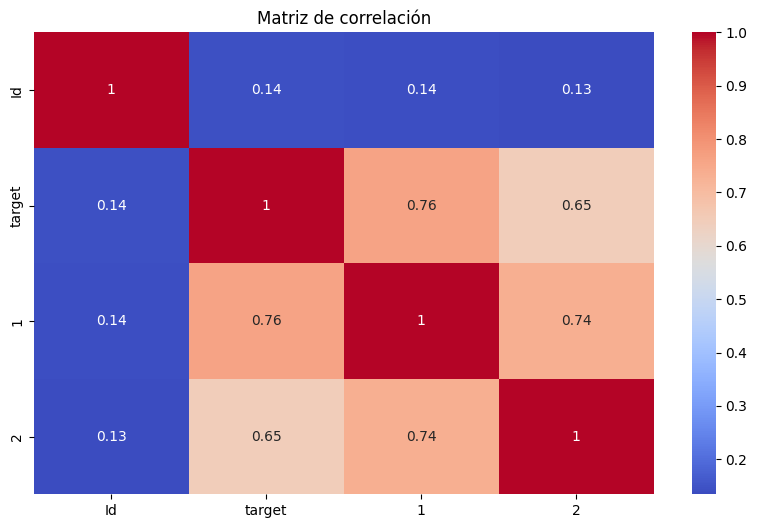

```python
import seaborn as sns
import matplotlib.pyplot as plt

plt.figure(figsize=(10,6))
sns.heatmap(df2_clean.corr(numeric_only=True), annot=True, cmap="coolwarm")
plt.title("Matriz de correlación")
plt.show()
```

## 9. Interpretación de correlaciones

A partir de la matriz de correlación se identifican las variables que tienen mayor relación con la variable objetivo (`target`). Esto permite entender qué variables aportan más información en el análisis.

```python
corr = df2_clean.corr(numeric_only=True)

corr["target"].sort_values(ascending=False)
```

```
target    1.000000
1         0.762797
2         0.645750
Id        0.142551
Name: target, dtype: float64
```

## 10. Conclusión de variables

Se identifican las variables con mayor impacto sobre el target, lo cual es clave para futuras etapas de modelado o análisis predictivo.

## 11. Conceptos base: Población vs Muestra

En este análisis trabajamos con una muestra de datos, por lo que las métricas estadísticas utilizadas corresponden a estimadores muestrales como media, desviación estándar, cuartiles y rango intercuartílico.

```python
df2_clean.describe()
```

|  | Id | target | 1 | 2 |
| --- | --- | --- | --- | --- |
| count | 147.000000 | 147.000000 | 145.000000 | 145.000000 |
| mean | 101.401361 | 5.021633 | 4.972621 | 4.906552 |
| std | 64.836640 | 2.122535 | 2.044076 | 2.001357 |
| min | 0.000000 | 1.300000 | 0.900000 | 1.040000 |
| 25% | 41.500000 | 3.720000 | 3.500000 | 3.400000 |
| 50% | 102.000000 | 4.600000 | 4.800000 | 4.830000 |
| 75% | 158.500000 | 6.275000 | 6.450000 | 6.200000 |
| max | 214.000000 | 11.700000 | 10.900000 | 11.000000 |

## 12. Análisis univariado - variables numéricas

Se analizan medidas como media, mediana, desviación estándar, cuartiles, mínimo y máximo.

### 📊 GRÁFICA (histograma)

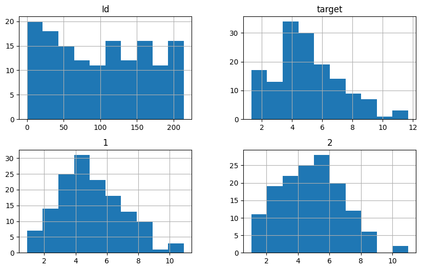

```python
import matplotlib.pyplot as plt

df2_clean.hist(figsize=(10,6))
plt.show()
```

### 📊 BOXPLOT (outliers)

```python
import plotly.express as px

# Genera un boxplot interactivo para todas las columnas numéricas de df2_clean
fig = px.box(df2_clean, title="Boxplots Interactivos de todas las variables")

fig.show()
```

[output not shown]

### 📊 VARIABLES CATEGÓRICAS (si existen)

```python
df2_clean.nunique()
```

```
Id        147
target     97
1         100
2          96
dtype: int64
```

### 📊 ANÁLISIS BIVARIADO

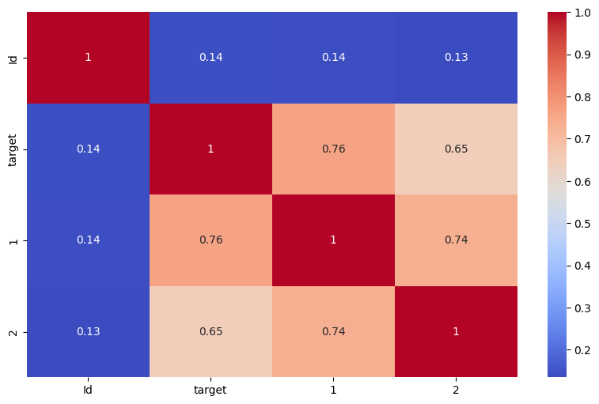

```python
import seaborn as sns
import matplotlib.pyplot as plt

plt.figure(figsize=(10,6))
sns.heatmap(df2_clean.corr(numeric_only=True), annot=True, cmap="coolwarm")
plt.show()
```

## 13. Análisis bivariado

Se estudia la relación entre variables numéricas mediante correlación de Pearson.

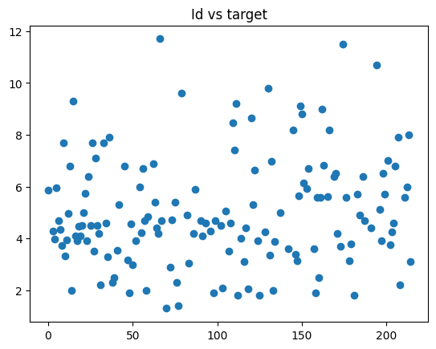

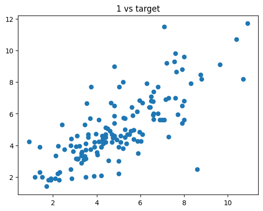

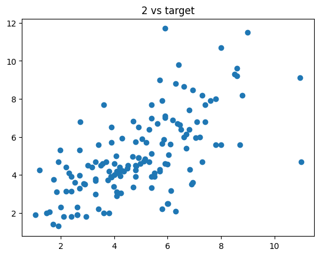

```python
for col in df2_clean.columns:
    if col != "target":
        plt.scatter(df2_clean[col], df2_clean["target"])
        plt.title(f"{col} vs target")
        plt.show()
```

## 14. Pruebas de hipótesis

Se evalúa si existen diferencias significativas entre variables mediante pruebas estadísticas con nivel de significancia de 0.05.

```python
from scipy import stats

stats.ttest_ind(df2_clean.dropna().iloc[:,0], df2_clean.dropna().iloc[:,1])
```

```
TtestResult(statistic=np.float64(17.73776343642485), pvalue=np.float64(5.3968561560794056e-48), df=np.float64(286.0))
```

## 15. Conclusiones finales

A partir del análisis exploratorio realizado se concluye que:

- El dataset presenta un alto porcentaje de valores faltantes en algunas variables.
- Se identifican variables con mayor relación con la variable objetivo `target`.
- Las variables numéricas presentan diferentes niveles de dispersión y comportamiento estadístico.
- El análisis permite entender la estructura del fenómeno estudiado y sentar bases para un posible modelo predictivo.

Este análisis corresponde a un proceso de limpieza, exploración y entendimiento de datos (EDA).